# Violence in East Europe

17/7/2019

## Violence in East Europe: Overview

The aim of this study is about what can be done to improve safety in countries of our fellows East-European citizens. Many different events, happened in the past, will be taken into consideration. They’re related to: - Riots - Protests - Violence against civilians - Explosions and remote violence

## …

[figure not shown]

Sun Tzu

> “If you know the enemy and know yourself, you need not fear the result of a hundred battles. If you know yourself but not the enemy, for every victory gained you will also suffer a defeat. If you know neither the enemy nor yourself, you will succumb in every battle.” Sun Tzu - The art of war

## The Dataset

- Data source: https://www.acleddata.com/
- Considered countries: Belarus, Greece, Moldova, Russia, Ukraine
- Many violent occurrences

## …

[figure not shown]

Miami Vice

```
##  [1] "data_id"          "iso"              "event_id_cnty"
##  [4] "event_id_no_cnty" "event_date"       "year"
##  [7] "time_precision"   "event_type"       "sub_event_type"
## [10] "actor1"           "assoc_actor_1"    "inter1"
## [13] "actor2"           "assoc_actor_2"    "inter2"
## [16] "interaction"      "region"           "country"
## [19] "admin1"           "admin2"           "admin3"
## [22] "location"         "latitude"         "longitude"
## [25] "geo_precision"    "source"           "source_scale"
## [28] "notes"            "fatalities"       "timestamp"
## [31] "iso3"
```

## The Dataset

```r
print(colnames(df))
```

```
##  [1] "id"          "event"       "sub_event"   "interaction" "country"
##  [6] "city"        "location"    "latitude"    "longitude"   "fatalities"
```

## Interactions visualization

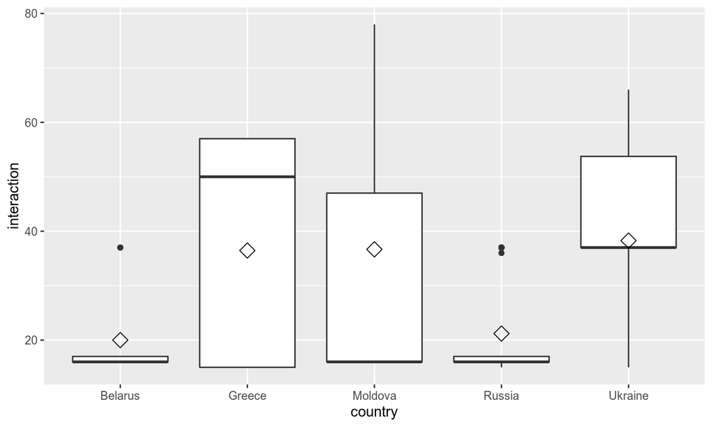

## Interaction vs Fatalities

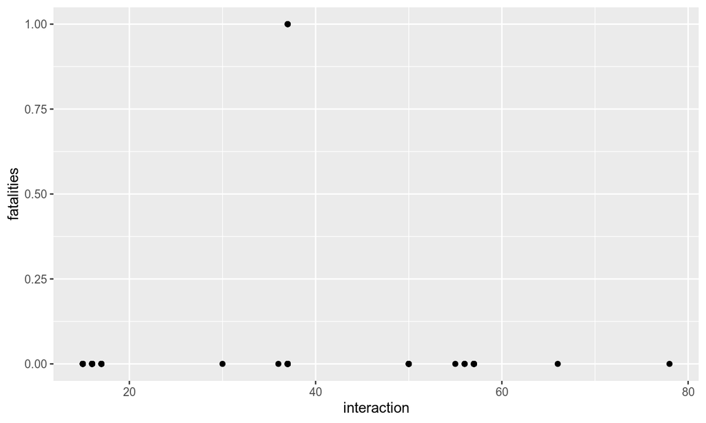

## Violent Occurrences Plot

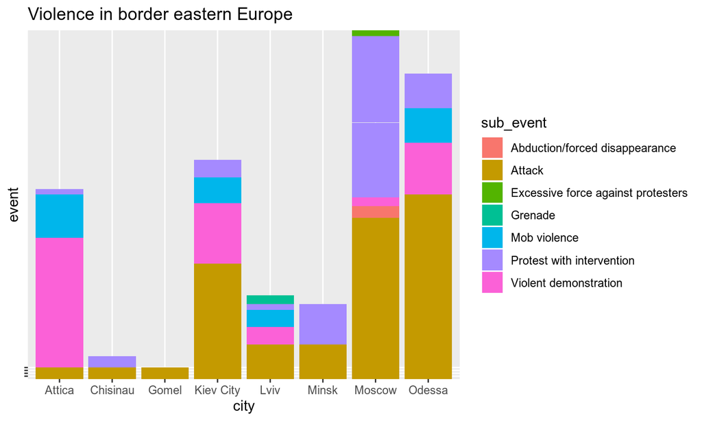

## Data wrangling

- Toolbox
  - dplyr: a grammar of data manipulation
  - tidyr: help you get to tidy data

[figure not shown]

A data wrangler in action

https://www.tidyverse.org/

## Data Wrangling Result

```
##      Mob violence Protest with intervention Violent demonstration Attack
## [1,]            0                         0                     0      1
## [2,]            0                         0                     0      1
## [3,]            0                         1                     0      0
## [4,]            0                         0                     0      1
## [5,]            0                         1                     0      0
## [6,]            0                         1                     0      0
##      Abduction/forced disappearance Excessive force against protesters
## [1,]                              0                                  0
## [2,]                              0                                  0
## [3,]                              0                                  0
## [4,]                              0                                  0
## [5,]                              0                                  0
## [6,]                              0                                  0
##      Grenade
## [1,]       0
## [2,]       0
## [3,]       0
## [4,]       0
## [5,]       0
## [6,]       0
```

[output not shown]

[output not shown]

## Bayesian Model

For each country

- The data generating process is a Multinomial distribution
  - Each parameter is a probability of a specific violent event
- We want to model our prior knowledge
  - Still don’t our model to be too constrained
  - We want data to speak, but not for themseves

## Dirichlet Distribution Visualization

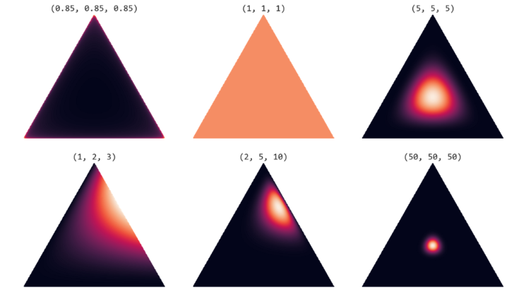

Dirichlet on a 2d simplex

## Prior Belief

Our prior belief has been elicited from the website https://www.numbeo.com/crime/country_result.jsp?country=Belarus

[figure not shown]

## The elicited scores

The scores have to be considered on a scale from 0 to 5 points.

| Registered act of violence | Belarus | Greece | Russia | Ukraine | Moldova |
| --- | --- | --- | --- | --- | --- |
| Mob Violence | 2 | 3 | 2 | 3 | 3 |
| Protest w/ Intervention | 3 | 2 | 3 | 3 | 3 |
| Violent Demonstration | 3 | 4 | 3 | 4 | 3 |
| Attack | 1 | 2 | 3 | 3 | 3 |
| Abduction | 1 | 2 | 1 | 2 | 2 |
| Excessive Force against Protesters | 2 | 3 | 4 | 5 | 5 |
| Grenade | 1 | 1 | 2 | 2 | 1 |

## Trace Plot

[figure not shown]

## Posteriors Plot

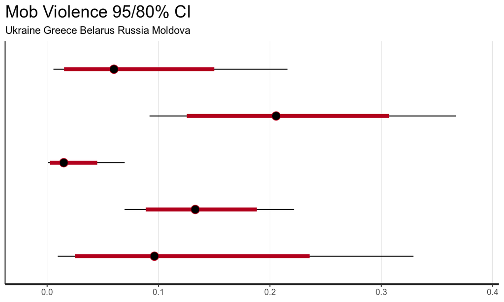

## Posteriors Plot

[figure not shown]

## Posteriors Plot

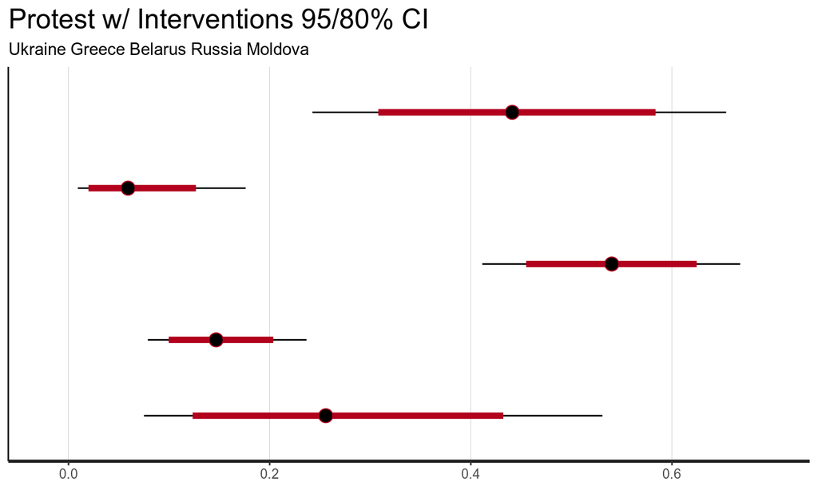

## Posteriors Plot

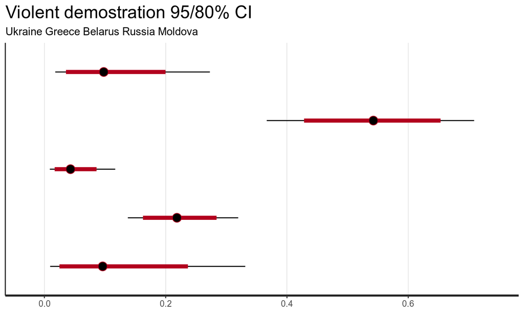

## Posteriors Plot

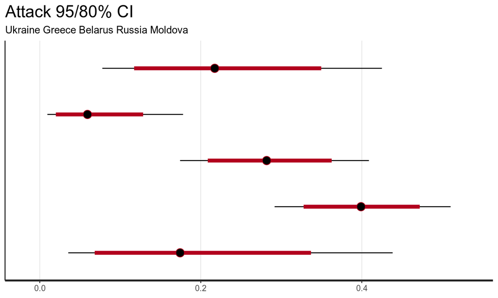

## Posteriors Plot

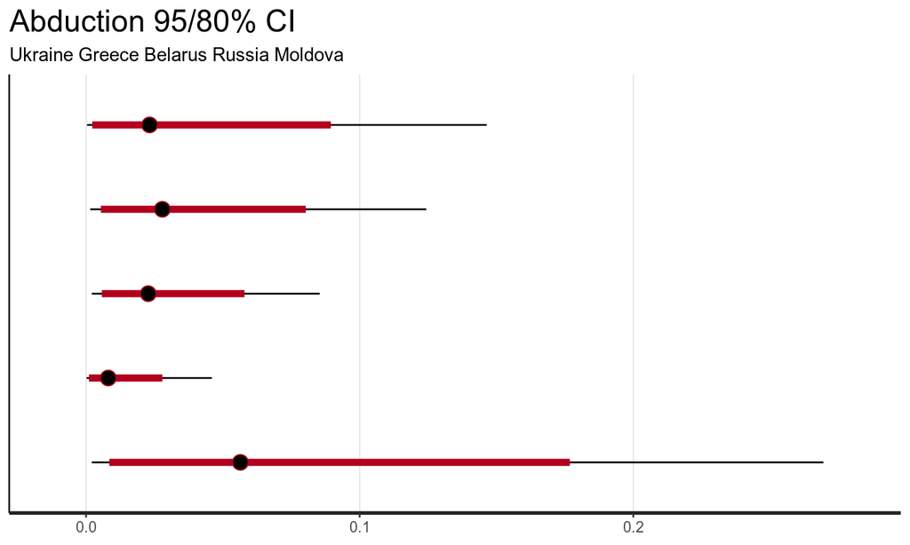

## Posteriors Plot

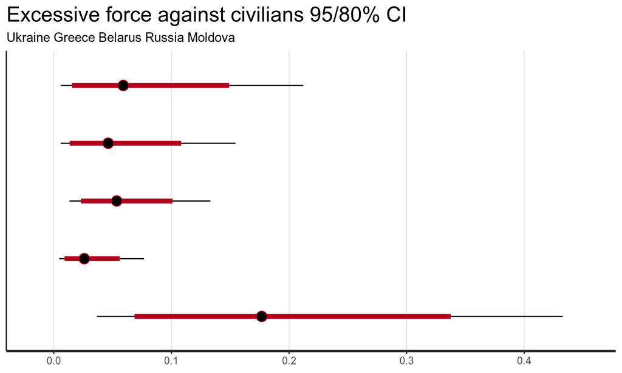

## Posteriors Plot

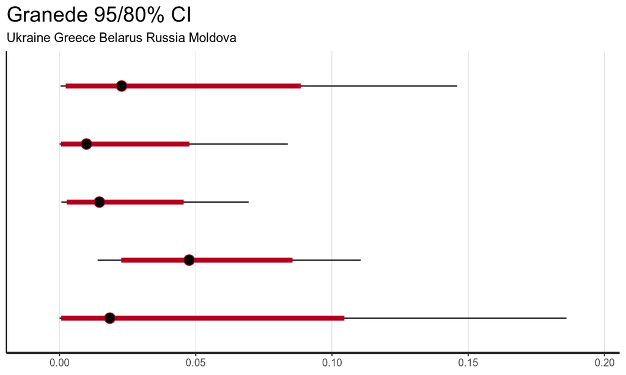

## Posteriors Plot

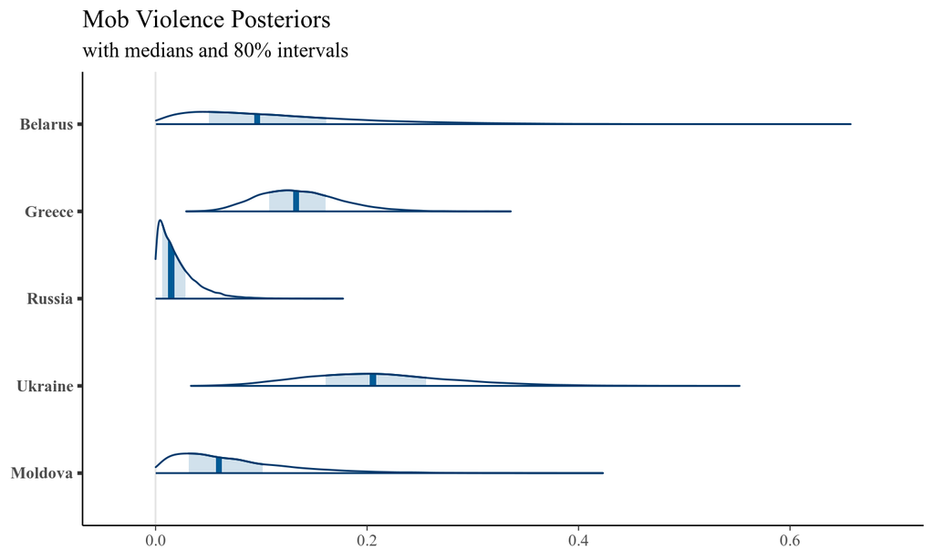

## Posteriors Plot

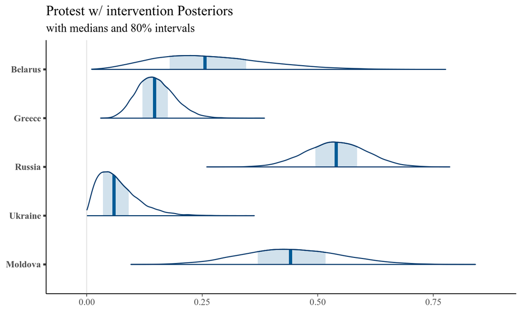

## Posteriors Plot

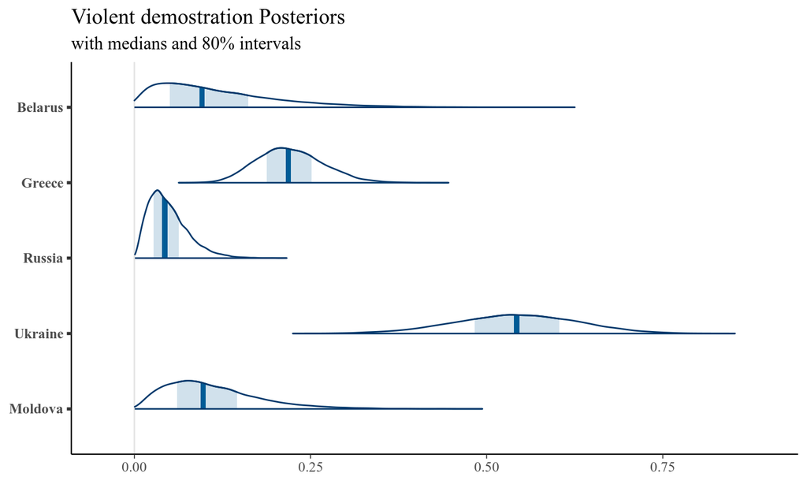

## Posteriors Plot

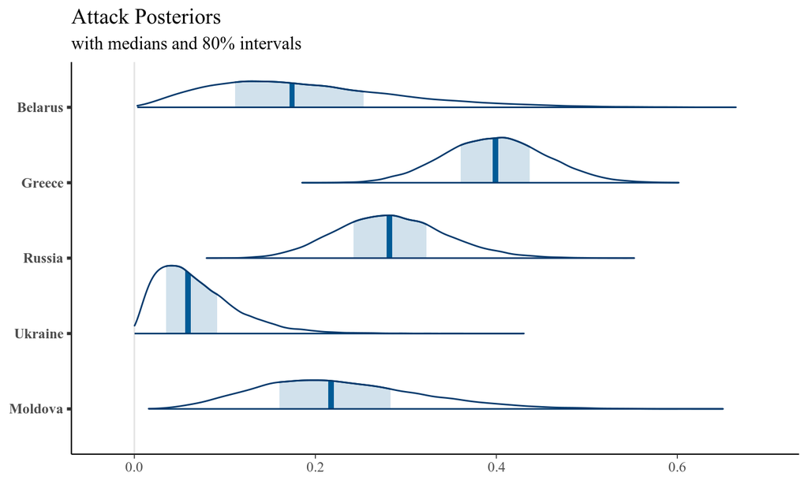

## Posteriors Plot

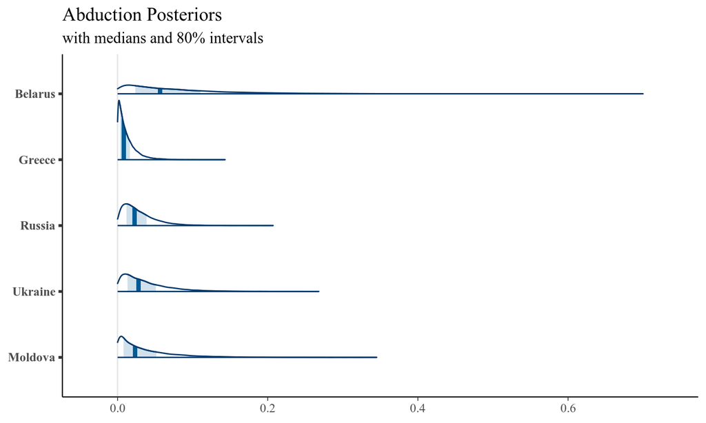

## Posteriors Plot

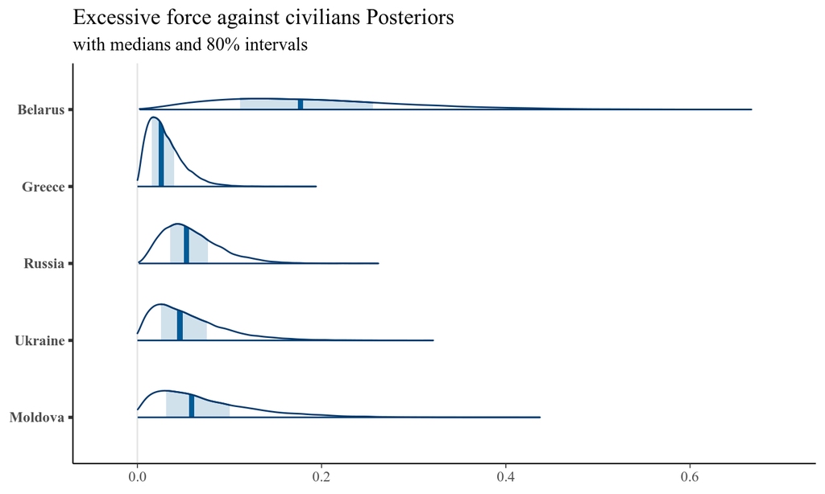

## Posteriors Plot

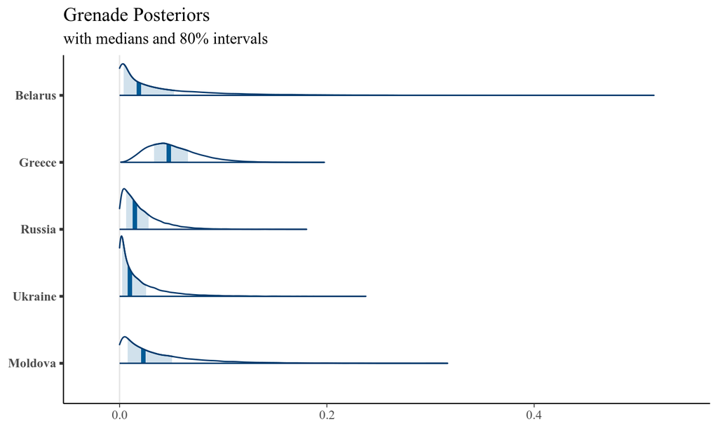

## Difference and Frequency of Crimes

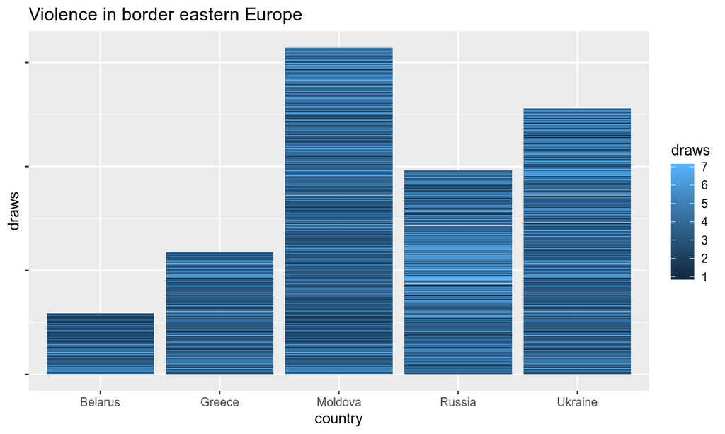